# Forecasting Energy Demand for Extreme Low Temperature Events in Texas

https://github.com/RuoxiWuRosie/ZhangWuZhu_ENV872_EDA_FinalProject.git

Judy Hua Zhu, Ruoxi Wu, Zhaoxin Zhang

2024-12-10

# Rationale and Research Questions – Background

The 2021 Texas winter storm was a severe event that caused widespread power outages, major damage, and significant hardship for many people. With temperatures dropping as low as -2°F (-19°C), which was much lower than the defined “extreme cold” temperature 32.0°F (0°C) [1], the storm pushed the state’s energy systems beyond their capacity.The combination of extreme cold and infrastructure failures showed how unprepared the system was for such events. This highlights the need to better understand cold weather extremes and their impact on energy systems to reduce risks and improve reliability during future storms.

Our research focuses on studying how often extreme cold events happen in Texas and how they affect local energy demand and electricity prices. By looking at past 8 years of temperature and energy data, we hope to find patterns and trends that can help predict grid demand during future cold days. This information can support better planning and help ensure Texas is more prepared to handle similar events in the future. Our goal is to improve resilience and energy security for the state during winter.

# Research Questions

1. How did local energy load and electricity price changed in 2016-2023?
2. How does the frequency of extreme cold days correlates with energy load and electricity price in Texas?
3. If following the past trend, how much energy will be demanded for preparing extreme cold days in 2024 and 2025?

# Dataset Information

Data used for this analysis is from different sources. Historical records of temperature were found in the archive API https://archive-api.open-meteo.com/v1/era5. Given the information on Texas’s latitude and longitude and the start and end dates from January 2016 to December 2023, the API archive could provide data on daily temperature in Texas from 2016 to 2023. The API gave the maximum and minimum temperatures in Texas from 2016 to 2023 in degrees Celsius. The Electric Reliability Council of Texas (ERCOT) gave hourly energy load data in Texas, from year 2016 to 2023, in MW. The U.S. Energy Information Administration (EIA) contained monthly average electricity price data from 2001 to 2024, and the unit was cent/kWh. The data for daily electricity prices was unavailable. All of the data from the three sources used in this analysis had a date column, which could ensure the time series analysis’s viability. The data had continuous data on daily temperature, hourly load, and monthly price, which would be used for both time series and linear model analysis. The data and sources are listed below (Table 3.1).

Table 3.1: Table summarizing the data sources

| Sources | Data |
| --- | --- |
| API | Texas Daily Max and Min Temperature |
| ERCOT | Texas Hourly Energy Load |
| EIA | Texas Monthly Electricity Price |

# Data Wrangling

The API data contained three columns: date, daily max temperature, and daily min temperature. The date column was in “character” format and thus needed to be converted to “date” format using the as.Date() code for the following analysis.

The raw ERCOT data contained hourly energy load data, but the analysis needed to be done at the daily level of energy load. Thus, the ERCOT’s data was aggregated and converted from hourly data to daily data. The ERCOT data had 10 columns: Date and Hourly Energy Load in MW via 9 different regions or standards. The analysis chose to use the ERCOT column, which represents total energy load by ERCOT’s service in Texas, selecting only two columns from the data: Date and ERCOT. The official website did not provide aggregated data from 2016 to 2023. Instead, it provided each year’s data. The data from 2016 to 2023 was aggregated in one data called “EnergyLoad_Daily.” This data would be used for analysis and visualization. Daily energy load data was then aggregated into monthly data for later analysis.

Finally, for electricity price, the EIA’s data contains 8 variables, including the date and electricity price via different end-use. This analysis would use the average electricity price for all sectors, so only two columns were selected: Date and Average Electricity Price among All Sectors. The data included information from 2001 to 2024, while the analysis only needed data from 2016 to 2023. Therefore, we filtered data from row 15 to row 96, selecting date only from 2016 to 2023.

All the data’s Date columns were converted to “date” format, and all other columns were converted to “numeric” format to make the latter analyses available. The raw data was uploaded to the “Data/Raw” file, and the processed datasets: monthly electricity price, daily energy load, monthly energy load, and daily temperature, were uploaded to the “Data/Processed” file in CSV format for the visualization, linear model analysis, and time series analysis. Please see DataWrangling.Rmd for details in preliminary data wrangling.l

# Exploratory Analysis

## Extreme cold days in Texas from 2016-2023

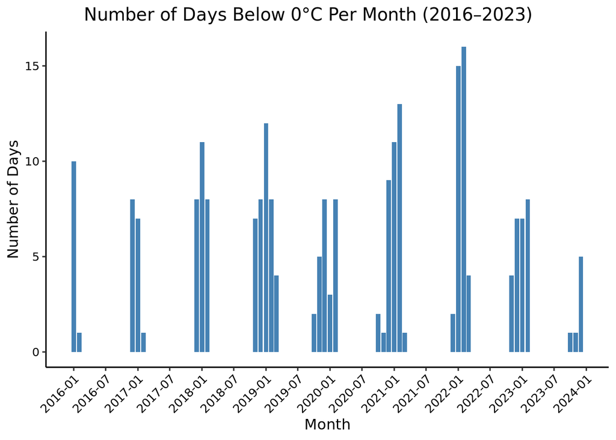

Fig.1 Number of days below freezing temperature (0 degree celsius) in Texas.

## Energy Load in Texas from 2016-2023

According to the line graph from 2016 to 2023, the energy load is generally increasing overtime with great pattern of seasonality, and it has spiked in mid-2023. General trend will be explained later in time series analysis.

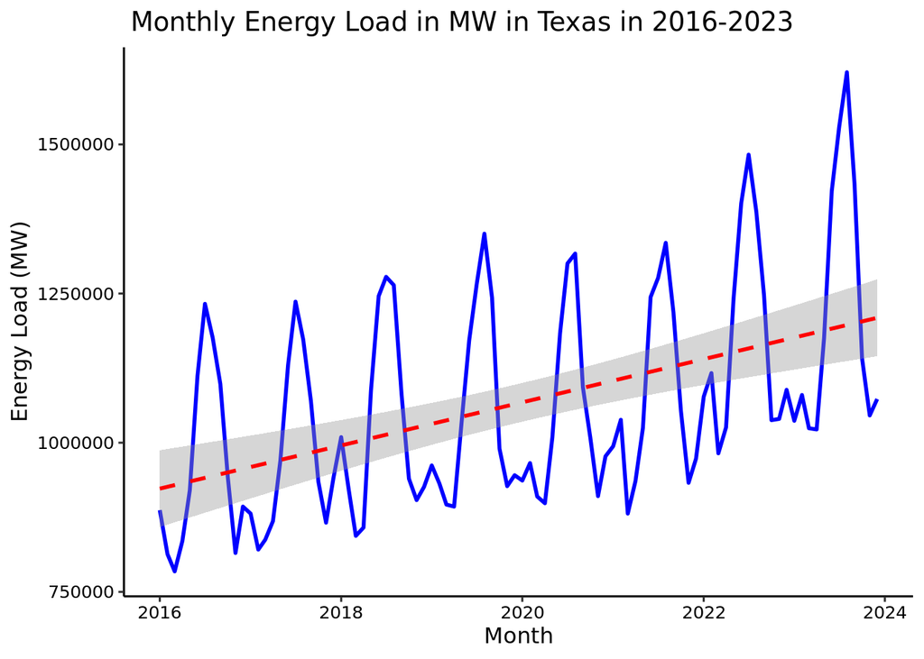

Fig.3 Averaged daily energy load from year 2016 to 2023 in Texas by month.

## Monthly electricity price in Texas from 2016-2023

The electricity price in Texas is increasing overtime from 2016-2023 with slight but less consistent seasonality. However, the electricity price spike around early 2021, which could be a reflection from the large-scale blackout in the winter in Texas. The state-wide grid and local distribution systems were struggling to recover to cater the demand from the local residents and business during and right after the cold-front.

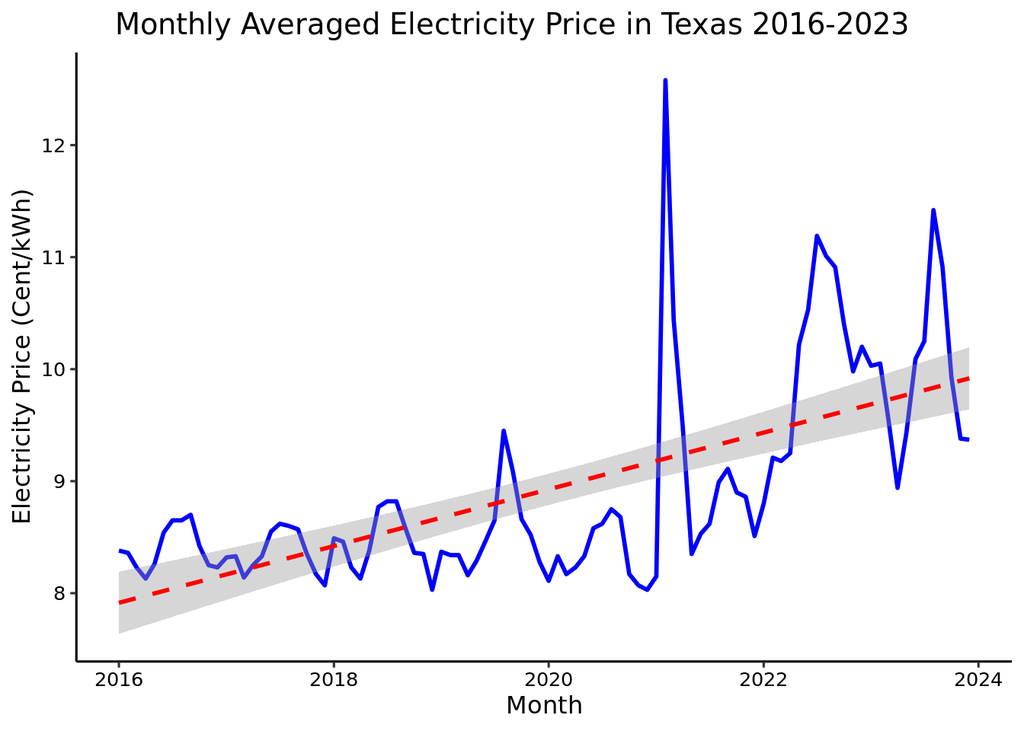

Fig.3 Avearged monthly electricity price (cent/kWh) from year 2016 to 2023 in Texas.

# Analysis

## Question 1: How did local energy load and electricity price changed in 2016-2023?

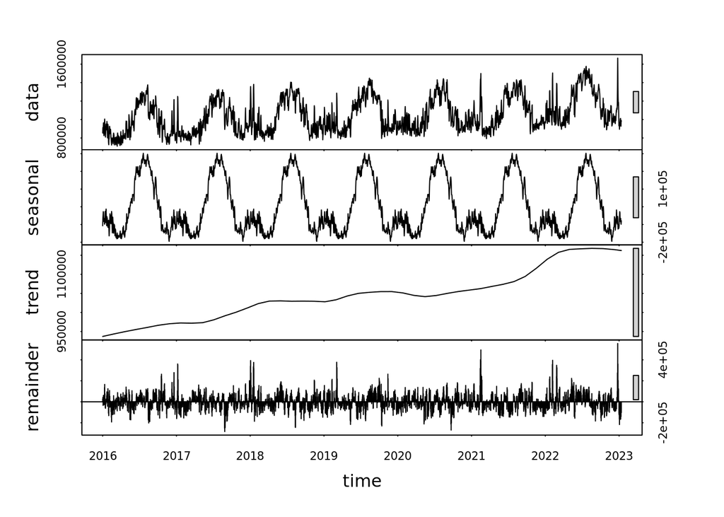

Fig.4 Visualization of Time Series Analysis of the daily energy load from 2016 to 2023 in Texas. Trend = data - seasonal - reminder

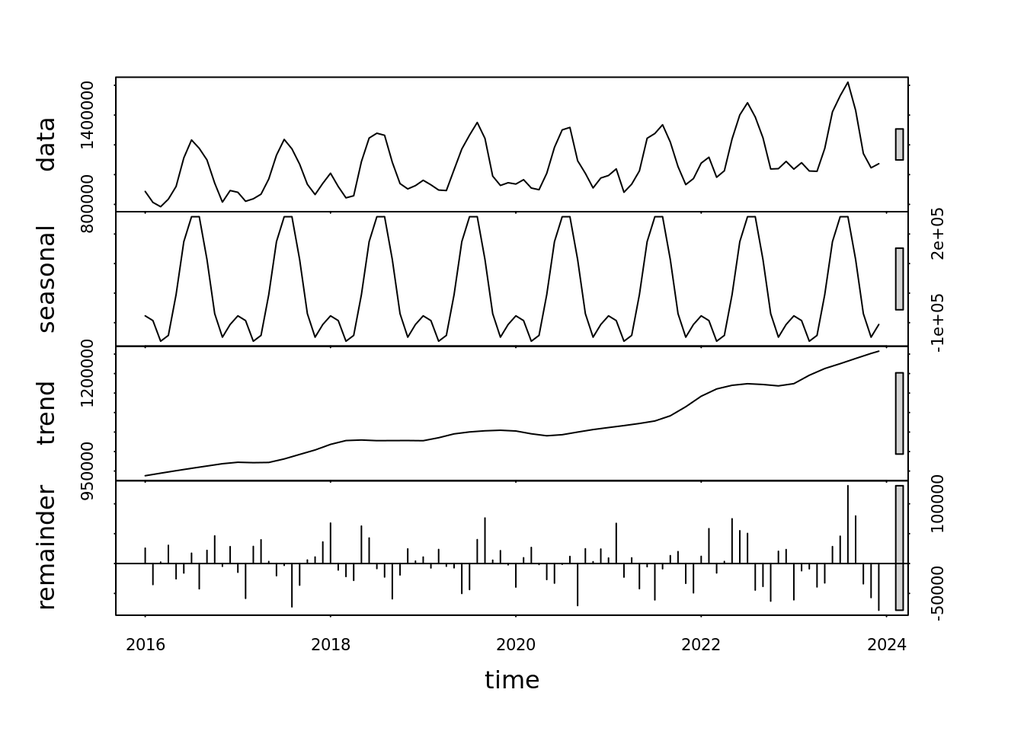

Fig.5 Visualization of Time Series Analysis of the averaged daily energy load from 2016 to 2023 in Texas by month

For electricity price, we also did time series analysis and seasonal Mann Kendall test; however, since electricity price is influenced by multiple factors aside from seasonality, such as market dynamics and policies, we also run a normal Mann Kendall test on de-trended electricity data. Below is the time series analysis graph of average monthly electricity price; the clear peak around 2021 indicates the storm event, which is 12.58 cents/kWh.

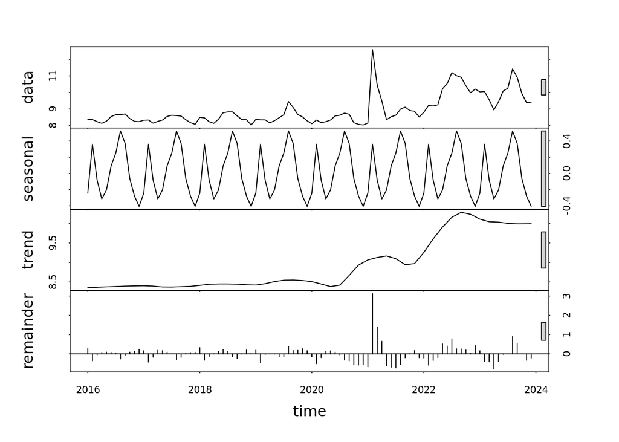

Fig.6 Visualization of Time Series Analysis of the averaged monthly electricity price from 2016 to 2023 in Texas

Table 1. Results of Seasonal Mann Kendall and Mann Kendall tests with detrended data.

```
##         Parameter Seasonal_MannKendall Detrended_MannKendall
## 1           Score           1.6200e+02             2.112e+03
## 2 2-sided p-value           5.6949e-09             2.220e-16
```

As shown in the table, both test results shows that electricity price has significantly increased in the past 8 years, with high score value and very low p-values. Detrended Mann Kendall test results show a much higher increasing tendency with very high possibility.

## Question 2: How does the frequency of extreme cold days correlates with energy load and electricity price?

We used linear models analysis to find how frequency of extremely cold days impacts energy load and electricity price. The analysis shows if the frequency of extreme cold days impacts energy load and electricity price or not. The report first analyzed the cold day frequency and energy load.

Table 2 Hypotheses

| Hypothesis |  |
| --- | --- |
| H0 | The frequency of extremely cold days in a month has no impacts on the average amount of monthly energy load |
| Ha | The frequency of extremely cold days in a month has impacts on the average amount of monthly energy load |

Table 3 Results

```
##                        Parameter       Value
## 1                        P-Value 4.38000e-03
## 2         Intercept Estimate Std 8.73984e+05
## 3 Extreme_Cold_days Estimate Std 1.19200e+04
```

The P-value is 0.00438, which is smaller than the significance level 0.05, so we reject the null hypothesis that number of extreme cold days has no impact on energy load. There is strong evidence that cold day frequency has a significant effect on energy load. When there is no extreme cold day, the energy load is estimated to be 873,984 MW. For every one additional extreme cold day, the monthly average energy load increases by 11,920 MW.

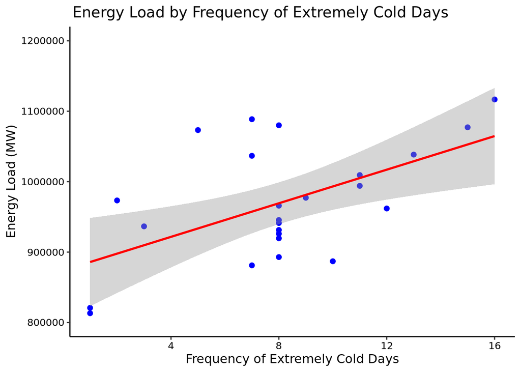

Fig.7 Linear regression between the Energy Load and # of extremely cold days (<0 degree Celsius).

Table 4 Hypotheses

| Hypothesis |  |
| --- | --- |
| H0 | The average energy load in a month has no impacts on the monthly electricity price |
| Ha | The average energy load in a month has impacts on the monthly electricity price |

Table 5 Results

```
##                        Parameter     Value
## 1                        P-Value 9.220e-03
## 2         Intercept Estimate Std 1.450e+00
## 3 Extreme_Cold_days Estimate Std 7.772e-06
```

The p-value of energy load is 0.00922, which is smaller than the significance level 0.05, so we reject the null hypothesis that the average energy load in a month has no impacts on the monthly electricity price. There is strong evidence that the average energy load in a month has has a significant effect on electricity price. When the energy load is 0, the price will be 1.450e+00 cent, and for every one additional MW in energy load, the electricity price will increase by 7.772e-06 cent per MW.

## Question 3: If following the past trend, how much energy will be demanded for preparing extreme cold days in 2024 and 2025?

Lastly, we hope to predict energy load in 2024 and 2025 based on historical data. We will use Autoregressive Integrated Moving Average (ARIMA) package to do a simple forecasting using historical energy load data from 2016 to 2023. However, daily energy load data will contain too much noise and excessive workload for the function to run; therefore, we choose to use averaged daily load of each months.

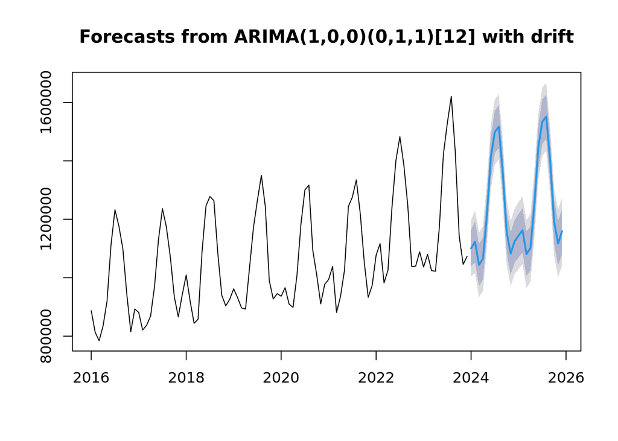

Fig.8 Forcasted Results of the Prediction of Energy Load in 2024 and 2025

The ARIMA test result shows that for the incoming winter (December 2024, Janurary and Feburary 2025), daily energy load in a normal winter day in Texas is predicted at 1124614 to 1162327 MW. We are at 95% confidence for the actual energy loaded be as high as 1278089 MW in Feburary and as low as 1013169.5 in December.

# Summary and Conclusions

Our analysis of extreme cold weather, energy demand and electricity pricing in Texas between 2016 and 2023 highlights several critical conclusions, corresponding to our three research questions proposed.

### How does the frequency of extreme cold days correlates with energy load and electricity price in Texas?

A linear regression model showed that each additional extreme cold day in a month increases the monthly average energy load by 11,920 MW. This relationship was statistically significant, with a p-value of 0.00438, indicating that extreme cold days are a strong predictor of increased energy demand.

### If following the past trend, how much energy will be demanded for preparing extreme cold days in 2024 and 2025?

Based on the ARIMA test results, the predicted daily energy demand for normal winter days in Texas during December 2024 through February 2025 ranges from 1,124,614 to 1,162,327 MW. However, with 95% confidence, the energy demand could peak as high as 1,278,089 MW in February or drop to as low as 1,013,169.5 MW in December. These projections emphasize the importance of strengthening energy infrastructure and planning to handle peak demands during extreme cold spells in Texas. Preparing the grid to ensure a reliable energy supply will be crucial for ERCOT to avoid future disruptions and keep systems running smoothly throughout the winter.

# References

<[1] NOAA’s National Weather Service. n.d. “Stay Safe in the Extreme Cold.” https://www.weather.gov/dlh/extremecold.\>